# Human Activity Recognition - a brief ML approach

[Javier Estraviz](https://github.com/estraviz)

August 23, 2015

# Synopsis

This exercise corresponds to the course project for the Practical Machine Learning course in the Data Science specialization on Coursera. The data for this project correspond to a well-known Human Activity Recognition experiment (see: http://groupware.les.inf.puc-rio.br/har).

Our goal is to predict the classe variable in the training set. We’ll explain the assumptions adopted below and compare the results offered by a couple of models of our interest.

# Data Processing

We begin by setting up manually the working directory to the location of this current file. Then, we create (if it does not exist yet) a new directory where the data of the project will be allocated:

```r
library(caret)
library(randomForest)
```

```r
if(!file.exists("./data")) {
  dir.create("data")
}

if(!file.exists("./data/pml-training.csv")) {
  urlTrain <- "https://d396qusza40orc.cloudfront.net/predmachlearn/pml-training.csv"
  download.file(urlTrain,destfile="./data/pml-training.csv",method="curl")
}
pmlTraining <- read.csv("./data/pml-training.csv", header=TRUE,
                        na.strings=c("", "NA", "#DIV/0!"))

if(!file.exists("./data/pml-testing.csv")) {
  urlTest <- "https://d396qusza40orc.cloudfront.net/predmachlearn/pml-testing.csv"
  download.file(urlTest,destfile="./data/pml-testing.csv",method="curl")
}
pmlTesting <- read.csv("./data/pml-testing.csv", header=TRUE,
                       na.strings=c("", "NA", "#DIV/0!"))
```

Note that we have used some string values for NA values. This is because we have first downloaded the files and inspected the data. Columns with NA’s will be useless and eliminated from our analysis.

We now perform the following commands to inspect what we’ve got by now:

```r
dim(pmlTraining)
```

```
## [1] 19622   160
```

```r
dim(pmlTesting)
```

```
## [1]  20 160
```

So 19,622 observations and 160 features in the original training set and only 20 observations and the same number of features in the original testing set.

As we he mentioned above, we eliminate columns with NA values, this way:

```r
pmlTrainingWithoutNA <- pmlTraining[, colSums(is.na(pmlTraining)) == 0]
pmlTestingWithoutNA <- pmlTesting[, colSums(is.na(pmlTesting)) == 0]

dim(pmlTraining)
```

```
## [1] 19622   160
```

```r
dim(pmlTesting)
```

```
## [1]  20 160
```

```r
pmlTrainingOnlyValidColumns <- pmlTrainingWithoutNA[, -(1:7)]
pmlTestingOnlyValidColumns <- pmlTestingWithoutNA[, -(1:7)]
```

# Data slicing

Now, we will be working only with the original training set data (with the processing performed above) and set aside the 20 rows of testing data for the second part of the exercise. Thus, we split this training set into a new training set (70% of the cases) and a new testing set (the remaining 30%):

```r
set.seed(12345)
inTrain <- createDataPartition(y=pmlTrainingOnlyValidColumns$classe, p=0.7,
                               list=FALSE)
training <- pmlTrainingOnlyValidColumns[inTrain, ]
testing <- pmlTrainingOnlyValidColumns[-inTrain, ]
```

# Prediction models

Machine Learning models effectiveness depends heavily on the fine tuning on some parameters. Here we are going to use a couple of models and compare results. We want to compare the accuracy of the gradient boosted model (gbm) vs the random forest model (RF).

```r
modelFit <- train(classe ~., data=training, method="gbm", verbose=FALSE)
print(modelFit)
```

```
## Stochastic Gradient Boosting
##
## 13737 samples
##    52 predictor
##     5 classes: 'A', 'B', 'C', 'D', 'E'
##
## No pre-processing
## Resampling: Bootstrapped (25 reps)
## Summary of sample sizes: 13737, 13737, 13737, 13737, 13737, 13737, ...
## Resampling results across tuning parameters:
##
##   interaction.depth  n.trees  Accuracy   Kappa      Accuracy SD
##   1                   50      0.7519229  0.6853213  0.008217987
##   1                  100      0.8193481  0.7712818  0.005269181
##   1                  150      0.8513781  0.8118579  0.005657194
##   2                   50      0.8532293  0.8139869  0.005963237
##   2                  100      0.9030903  0.8773206  0.005563830
##   2                  150      0.9276625  0.9084392  0.004106362
##   3                   50      0.8943972  0.8662716  0.005414426
##   3                  100      0.9385502  0.9222170  0.004529085
##   3                  150      0.9578546  0.9466603  0.002704551
##   Kappa SD
##   0.010386687
##   0.006674798
##   0.007182609
##   0.007490087
##   0.006993702
##   0.005185679
##   0.006841105
##   0.005734057
##   0.003419676
##
## Tuning parameter 'shrinkage' was held constant at a value of 0.1
##
## Tuning parameter 'n.minobsinnode' was held constant at a value of 10
## Accuracy was used to select the optimal model using  the largest value.
## The final values used for the model were n.trees = 150,
##  interaction.depth = 3, shrinkage = 0.1 and n.minobsinnode = 10.
```

```r
prediction <- predict(modelFit, testing[,-ncol(testing)])
tab <- table(prediction, testing$classe)
tab
```

```
##
## prediction    A    B    C    D    E
##          A 1646   35    0    1    2
##          B   20 1070   35    2   17
##          C    3   31  970   31    3
##          D    5    3   20  918   20
##          E    0    0    1   12 1040
```

```r
confusionMatrix(prediction, testing$classe)
```

```
## Confusion Matrix and Statistics
##
##           Reference
## Prediction    A    B    C    D    E
##          A 1646   35    0    1    2
##          B   20 1070   35    2   17
##          C    3   31  970   31    3
##          D    5    3   20  918   20
##          E    0    0    1   12 1040
##
## Overall Statistics
##
##                Accuracy : 0.959
##                  95% CI : (0.9537, 0.964)
##     No Information Rate : 0.2845
##     P-Value [Acc > NIR] : < 2.2e-16
##
##                   Kappa : 0.9482
##  Mcnemar's Test P-Value : 0.0001477
##
## Statistics by Class:
##
##                      Class: A Class: B Class: C Class: D Class: E
## Sensitivity            0.9833   0.9394   0.9454   0.9523   0.9612
## Specificity            0.9910   0.9844   0.9860   0.9902   0.9973
## Pos Pred Value         0.9774   0.9353   0.9345   0.9503   0.9877
## Neg Pred Value         0.9933   0.9854   0.9884   0.9906   0.9913
## Prevalence             0.2845   0.1935   0.1743   0.1638   0.1839
## Detection Rate         0.2797   0.1818   0.1648   0.1560   0.1767
## Detection Prevalence   0.2862   0.1944   0.1764   0.1641   0.1789
## Balanced Accuracy      0.9871   0.9619   0.9657   0.9713   0.9792
```

We obtain an accuracy of 95.9% with this model. The previous print instruction provides us with information of the optimal parameters.

Now it’s time for the RF model. First, we tune the randomForest for the optimal mtry parameter. We use 150 trees (for comparison with the previous model). We do this with tuneRF, as follows:

```r
tuneRF(x = training[, -ncol(training)], y=training[, ncol(training)],
       stepFactor=0.5, mtryStart=2, ntreeTry=150)
```

```
## mtry = 2  OOB error = 0.8%
## Searching left ...
## mtry = 4     OOB error = 0.6%
## 0.2545455 0.05
## mtry = 8     OOB error = 0.56%
## 0.06097561 0.05
## mtry = 16    OOB error = 0.68%
## -0.2077922 0.05
## Searching right ...
## mtry = 1     OOB error = 1.21%
## -1.155844 0.05
```

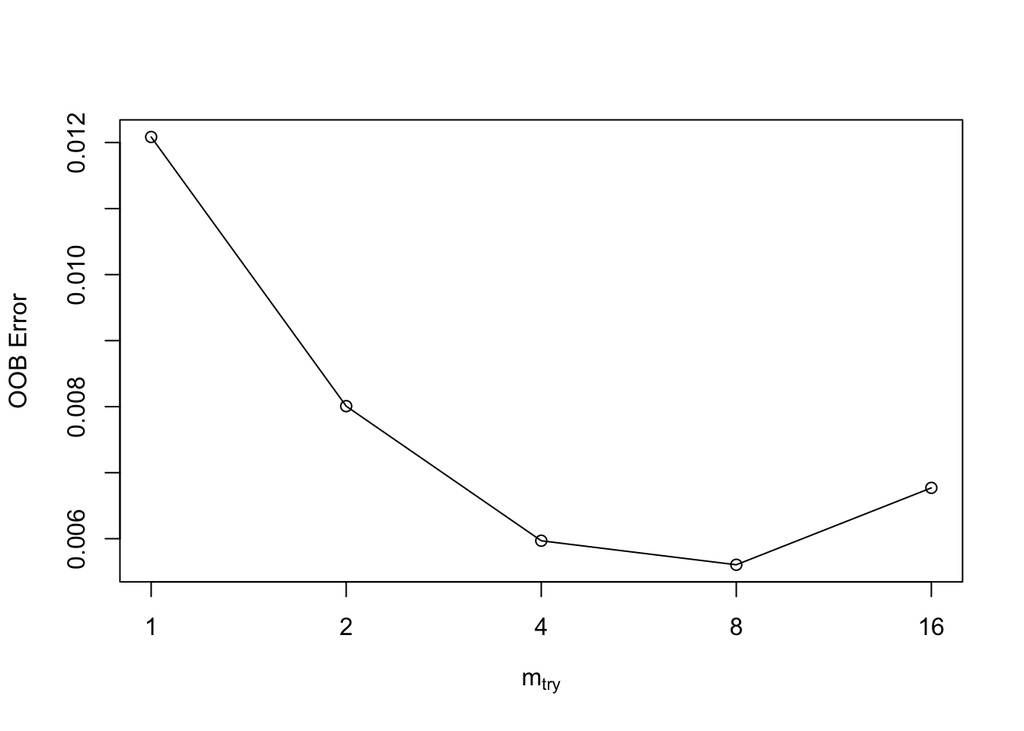

```
##        mtry    OOBError
## 1.OOB     1 0.012084152
## 2.OOB     2 0.008007571
## 4.OOB     4 0.005969280
## 8.OOB     8 0.005605300
## 16.OOB   16 0.006770037
```

```r
modelRF <- randomForest(classe ~., data=training, mtry=4, ntree=150)
print(modelRF)
```

```
##
## Call:
##  randomForest(formula = classe ~ ., data = training, mtry = 4,      ntree = 150)
##                Type of random forest: classification
##                      Number of trees: 150
## No. of variables tried at each split: 4
##
##         OOB estimate of  error rate: 0.6%
## Confusion matrix:
##      A    B    C    D    E class.error
## A 3902    3    0    0    1 0.001024066
## B   14 2639    5    0    0 0.007148232
## C    0   18 2374    4    0 0.009181970
## D    0    0   29 2221    2 0.013765542
## E    0    0    1    6 2518 0.002772277
```

```r
predictionRF <- predict(modelRF, testing[,-ncol(testing)])
tabRF <- table(predictionRF, testing$classe)
tabRF
```

```
##
## predictionRF    A    B    C    D    E
##            A 1673   11    0    0    0
##            B    1 1122   12    0    0
##            C    0    6 1012   19    0
##            D    0    0    2  945    3
##            E    0    0    0    0 1079
```

```r
confusionMatrix(predictionRF, testing$classe)
```

```
## Confusion Matrix and Statistics
##
##           Reference
## Prediction    A    B    C    D    E
##          A 1673   11    0    0    0
##          B    1 1122   12    0    0
##          C    0    6 1012   19    0
##          D    0    0    2  945    3
##          E    0    0    0    0 1079
##
## Overall Statistics
##
##                Accuracy : 0.9908
##                  95% CI : (0.988, 0.9931)
##     No Information Rate : 0.2845
##     P-Value [Acc > NIR] : < 2.2e-16
##
##                   Kappa : 0.9884
##  Mcnemar's Test P-Value : NA
##
## Statistics by Class:
##
##                      Class: A Class: B Class: C Class: D Class: E
## Sensitivity            0.9994   0.9851   0.9864   0.9803   0.9972
## Specificity            0.9974   0.9973   0.9949   0.9990   1.0000
## Pos Pred Value         0.9935   0.9885   0.9759   0.9947   1.0000
## Neg Pred Value         0.9998   0.9964   0.9971   0.9961   0.9994
## Prevalence             0.2845   0.1935   0.1743   0.1638   0.1839
## Detection Rate         0.2843   0.1907   0.1720   0.1606   0.1833
## Detection Prevalence   0.2862   0.1929   0.1762   0.1614   0.1833
## Balanced Accuracy      0.9984   0.9912   0.9906   0.9896   0.9986
```

# Appendix

We have to use the provided function to obtain predictions of the original test set, for our considered best model in this analysis (modelRF). The following set of instructions write twenty txt files that will be used in the submission for the autograder on Coursera:

```r
pml_write_files = function(x) {
    for (i in 1:length(x)){
        filename = paste0("problem_id_",i,".txt")
        write.table(x[i], file=filename, quote=FALSE, row.names=FALSE,
                    col.names=FALSE) }
}

answers <- as.character(predict(modelRF, newdata=pmlTestingOnlyValidColumns))
pml_write_files(answers)
```

[output not shown]